# Data Analysis Using R Package icensmis

Yibai Zhao

November 11, 2015

In this section, we would introduce two functions in the package *icensmis*.

## 1. Data Simulation

### 1.1 Function

```
datasim(N, blambda, testtimes, sensitivity, specificity, betas = NULL, twogroup = NULL, pmiss = 0, pcensor = 0, design = "MCAR", negpred = 1, time.varying = F)
```

`datasim()` simulates a longitudinal form data frame of N subjects with misclassified outcomes, assuming each subject receives a sequence of pre-scheduled tests for disease status ascertainment. Each test is subject to error, characterized by sensitivity and specificity. An exponential distribution is assumed for the time to event of interest.

- **N**: total number of subjects to be simulated
- **blambda**: baseline hazard rate
- **testtimes**: a vector of pre-scheduled test times
- **sensitivity**: the sensitivity of test
- **specificity**: the specificity of test
- **betas**: a vector of regression coefficients of the same length as the covariate vector. If betas = NULL then the simulated dataset corresponds to the one sample setting. If betas $\neq$ NULL and twogroup $\neq$ NULL then the simulated dataset corresponds to the two group setting, and the first value of betas is used as the coefficient for the treatment group indicator. If betas $\neq$ NULL and twogroup = NULL, then the covariates are ~ i.i.d. N(0, 1), and the number of covariates is determined by the length of betas.
- **twogroup**: corresponds to the proportion of subjects allocated to the baseline (reference) group in the two-group setting. For the two-group setting, this variable should be between 0 and 1. For the one sample and multiple ($\geq$ 2) covariate setting, this variable should be set to NULL. That is, when betas !=NULL, set twogroup to equal the proportion of the subjects in the baseline group to obtain a simulated dataset corresponding to the two-group setting. Else, set twogroup=NULL to obtain either the one sample setting (betas=NULL) or continuous covariates (betas $\neq$ NULL).
- **pmiss**: a value or a vector (must have same length as testtimes) of the probabilities of each test being randomly missing at each test time. If pmiss is a single value, then each test is assumed to have an identical probability of missingness.
- **pcensor**: a value or a vector (must have same length as testtimes) of the probability of censoring at each visit, assuming censoring process is independent on other missing mechanisms.
- **design**: missing mechanism: “MCAR” or “NTFP”
- **negpred**: baseline negative predictive value, i.e. the probability of being truely disease free for those who were tested (reported) as disease free at baseline. If baseline screening test is perfect, then negpred = 1.
- time.varying: indicator whether fitting a time varying covariate model or not

Additional inputs include the values of the parameters $\varphi_1$ (sensitivity) and $\varphi_0$ (specificity) for self-report.

### 1.2 Example

Below is a sample data set of 1000 subjects simulated by the `datasim()` function.

```r
library(icensmis)
data <- datasim(N = 1000, blambda = 0.2, testtimes = 1:6,
     sensitivity = 0.7, specificity = 0.98, betas = c(0.5, 0.8, 1.0),
     twogroup = NULL, pmiss = 0.3, design = "NTFP")
```

```
##    ID       cov1        cov2       cov3 testtime result
## 1   1  0.2917518 -0.21832122  0.8360827        1      0
## 2   1  0.2917518 -0.21832122  0.8360827        2      1
## 3   2  0.3605408  0.02411084 -0.5145658        1      0
## 4   2  0.3605408  0.02411084 -0.5145658        2      0
## 5   2  0.3605408  0.02411084 -0.5145658        3      0
## 6   3  0.7323282  0.54841407  0.7653336        1      0
## 7   3  0.7323282  0.54841407  0.7653336        3      0
## 8   3  0.7323282  0.54841407  0.7653336        4      1
## 9   4 -0.6660202 -0.84799006  0.3088921        1      0
## 10  4 -0.6660202 -0.84799006  0.3088921        4      1
```

The structure of the input set is described below:

- **Subject id**: a unique id for each subject
- **Visit time**: the visit time corresponding to each observation. The number of unique visit times in the data determines the number of parameters ($\theta$).
- **Result**: the binary diagnostic test/self-report result, where 0 denotes a negative test (absence of event of interest) and 1 denotes a positive test. For self-reported outcomes, we assume that all results after the first positive are non-informative. Thus, all results after the first positive should be excluded from the dataset prior to analysis.
- **Covariates**: all explanatory variables needed in the model. If we want to fit a time-varying covariate model, we would need to add an observa- tion for each subject at baseline (time=0) providing baseline covariate values.

## 2. Data Analysis

### 2.1 Function

```
icmis(subject, testtime, result, data, sensitivity, specificity, formula = NULL, negpred = 1, time.varying = F, betai = NULL, initsurv = 0.5, param = 1, ...)
```

In the function call for the `icmis()` function, **subject** denotes subject id, **testtime** denotes visit time, **result** denotes binary (0 or 1) self-report, **data** denotes data frame, **sensitivity** denotes the value of $\varphi_1$, **specificity** denotes the value of $\varphi_0$ and **negpred** denotes the baseline negative predictive value ($\eta$). The **formula** argument is used to specify the covariates to be included in the model. Interaction terms can also be included - for example, $cov1+cov2+cov1*cov2$.

The returned result of the `icmis()` function includes the value of the log likelihood function at the MLE, estimated regression coefficients β, es- timated survival function at each visit time ($S_2, ..., S_{J+1}$), and covariance matrix corresponding to the estimated parameters.

### 2.2 Example

#### 2.2.1 One sample setting

We set `betas = NULL` and `twogroup = NULL` corresponding to the one sample setting. See example below:

```r
simdata1 <- datasim(N = 1000, blambda = 0.05, testtimes = 1:8, sensitivity = 0.7,
  specificity = 0.98, betas = NULL, twogroup = NULL, pmiss = 0.3, design = "MCAR")
```

```
##    ID testtime result
## 1   1        1      0
## 2   1        3      0
## 3   1        4      0
## 4   1        5      0
## 5   1        7      0
## 6   1        8      0
## 7   2        1      0
## 8   2        2      0
## 9   2        3      0
## 10  2        4      0
```

See function call for `icmis()` below:

```r
fit1 <- icmis(subject = ID, testtime = testtime, result = result, data = simdata1,
  sensitivity = 0.7, specificity= 0.98, formula = NULL, negpred = 1)
```

#### 2.2.2 Two group setting, and the two groups have same sample sizes

We set `twogroup = 0.5` corresponding to equal allocation. See example below:

```r
simdata2 <- datasim(N = 1000, blambda = 0.05, testtimes = 1:8, sensitivity = 0.7,
  specificity = 0.98, betas = 0.7, twogroup = 0.5, pmiss = 0.3, design = "MCAR")
```

```
##    ID group testtime result
## 1   1     1        1      0
## 2   1     1        2      0
## 3   1     1        5      0
## 4   1     1        6      0
## 5   1     1        7      0
## 6   1     1        8      0
## 7   2     1        2      0
## 8   2     1        4      0
## 9   2     1        5      1
## 10  2     1        6      0
```

Here, group is a dummy variable, and we include it into our formula as a covariate with the argument `formula = ~group`. See function call for `icmis()` below:

```r
fit2 <- icmis(subject = ID, testtime = testtime, result = result, data = simdata2,
  sensitivity = 0.7, specificity= 0.98, formula = ~group)
```

#### 2.2.3 Three covariates with coefficients 0.5, 0.8, and 1.0

We set `betas = c(0.5, 0.8, 1.0)` corresponding to three covariates, say $\beta_1, \beta_2, \beta_3$. `pmiss = 0.3` indicates the probability of missingness is 0.3 at each test time. See example below:

```r
simdata3 <- datasim(N = 1000, blambda = 0.05, testtimes = 1:8, sensitivity = 0.7,
  specificity = 0.98, betas = c(0.5, 0.8, 1.0), twogroup = NULL, pmiss = 0.3,
  design = "MCAR", negpred = 1)
```

```
##    ID        cov1       cov2       cov3 testtime result
## 1   1 -0.00530224 -0.8029602 -1.6162713        1      0
## 2   1 -0.00530224 -0.8029602 -1.6162713        3      0
## 3   1 -0.00530224 -0.8029602 -1.6162713        5      0
## 4   1 -0.00530224 -0.8029602 -1.6162713        8      1
## 5   2  0.25551222 -1.3300467 -0.3338254        1      0
## 6   2  0.25551222 -1.3300467 -0.3338254        2      1
## 7   2  0.25551222 -1.3300467 -0.3338254        3      0
## 8   2  0.25551222 -1.3300467 -0.3338254        6      0
## 9   2  0.25551222 -1.3300467 -0.3338254        8      0
## 10  3  1.75218488  0.8674124 -1.3009971        1      0
```

Here, since we have three covariates, so the argument should be `formula = ~cov1+cov2+cov3`. See function call for `icmis()` below:

```r
fit3 <- icmis(subject = ID, testtime = testtime, result = result, data = simdata3,
  sensitivity = 0.7, specificity= 0.98, formula = ~cov1+cov2+cov3, negpred = 1)
```

#### 2.2.4 Fit data with NTFP missing mechanism (the fitting is same as MCAR data)

Previously, we fit data with `MCAR` mechanism, which assumes that each test is subject to a constant, independent probability of missingness, while here we apply `NTFP` mechanism, which assumes all test results after first positive are missing. See example below:

```r
simdata4 <- datasim(N = 1000, blambda = 0.05, testtimes = 1:8, sensitivity = 0.7,
  specificity = 0.98, betas = c(0.5, 0.8, 1.0), twogroup = NULL, pmiss = 0.3,
  design = "NTFP", negpred = 1)
```

```
##    ID       cov1       cov2       cov3 testtime result
## 1   1  0.3642027  1.3795365 -1.7604420        1      0
## 2   1  0.3642027  1.3795365 -1.7604420        5      0
## 3   1  0.3642027  1.3795365 -1.7604420        6      0
## 4   1  0.3642027  1.3795365 -1.7604420        7      0
## 5   2 -0.1783708 -0.1856000 -2.0846844        1      0
## 6   2 -0.1783708 -0.1856000 -2.0846844        3      0
## 7   2 -0.1783708 -0.1856000 -2.0846844        7      0
## 8   3 -1.4881102 -0.6895938 -0.8916792        3      0
## 9   3 -1.4881102 -0.6895938 -0.8916792        5      0
## 10  3 -1.4881102 -0.6895938 -0.8916792        6      0
```

See function call for `icmis()` below:

```r
fit4 <- icmis(subject = ID, testtime = testtime, result = result, data = simdata4,
  sensitivity = 0.7, specificity= 0.98, formula = ~cov1+cov2+cov3, negpred = 1)
```

#### 2.2.5 Fit data with baseline misclassification

Previously, we assume that baseline screening test is perfect with argument`negpred = 1`, while in this section screening test is not perfect. See example below:

```r
simdata5 <- datasim(N = 2000, blambda = 0.05, testtimes = 1:8, sensitivity = 0.7,
  specificity = 0.98, betas = c(0.5, 0.8, 1.0), twogroup = NULL, pmiss = 0.3,
  design = "MCAR", negpred = 0.97)
```

```
##    ID       cov1      cov2       cov3 testtime result
## 1   1 -0.2182947  2.858214 -1.0660057        2      0
## 2   1 -0.2182947  2.858214 -1.0660057        3      0
## 3   1 -0.2182947  2.858214 -1.0660057        4      0
## 4   1 -0.2182947  2.858214 -1.0660057        6      1
## 5   1 -0.2182947  2.858214 -1.0660057        7      1
## 6   1 -0.2182947  2.858214 -1.0660057        8      1
## 7   2  0.6775557 -1.625910  0.3273019        1      0
## 8   2  0.6775557 -1.625910  0.3273019        2      0
## 9   2  0.6775557 -1.625910  0.3273019        3      0
## 10  2  0.6775557 -1.625910  0.3273019        4      0
```

See function call for `icmis()` below:

```r
fit5 <- icmis(subject = ID, testtime = testtime, result = result, data = simdata5,
  sensitivity = 0.7, specificity= 0.98, formula = ~cov1+cov2+cov3, negpred = 0.97)
```

#### 2.2.6 Fit data with time varying covariates

To incorporate time varying covariates, we assume that the covariate values are updated at each visit. Unlike the previous example, the values of the covariates at baseline (time = 0) must be present in the data frame. See example below:

```r
simdata6 <- datasim(N = 1000, blambda = 0.05, testtimes = 1:8, sensitivity = 0.7,
  specificity = 0.98, betas = c(0.5, 0.8, 1.0), twogroup = NULL, pmiss = 0.3,
  design = "MCAR", negpred = 1, time.varying = TRUE)
```

```
##    ID        cov1       cov2       cov3 testtime result
## 1   1  1.74815867 -0.9329671  0.7680458        0      0
## 2   1  1.74815867 -0.9329671  0.7680458        1      0
## 3   1 -1.79551959  2.0589911  0.5802627        7      0
## 4   2 -0.03836893 -0.2334605 -1.2912097        0      0
## 5   2 -0.03836893 -0.2334605 -1.2912097        1      0
## 6   2 -0.03836893 -0.2334605 -1.2912097        2      1
## 7   2 -0.03836893 -0.2334605 -1.2912097        3      0
## 8   2  0.80831622 -0.9250770 -0.4903339        4      0
## 9   2  0.80831622 -0.9250770 -0.4903339        6      0
## 10  3  0.41208286  0.6418758  0.6833347        0      0
```

The use of `icmis()` to fit the time-varying covariate model is identical to that of the time-invariant covariate model, with the exception that the argument `time.varying` is set to equal `TRUE`. See function call below:

```r
fit6 <- icmis(subject = ID, testtime = testtime, result = result, data = simdata6,
   sensitivity = 0.7, specificity= 0.98, formula = ~cov1+cov2+cov3, negpred = 1,
   time.varying = TRUE)
```

## 3. Shiny Application Instructions

Steps

1. Click “Choose File” to upload a dataset. If you upload successfully, you will see a message below.

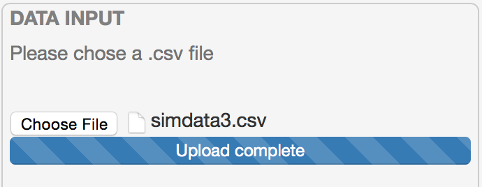

2. Type in separator character, if no, leave it blank. Then, “Upload” your file. At this time, in your right-hand side, you will see “Review your dataset” panel opened with a brief review of your dataset, including all the variables and the first six observations. Make sure it’s the right dataset you want to analyse, and move to next step.

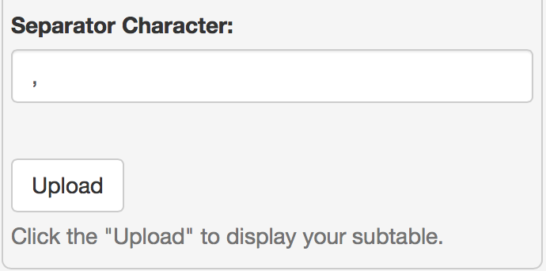

3. Use the select box to choose equivalent variable, given all the variables we read from your dataset. For **Covariate** you could choose either one or multiple into study.

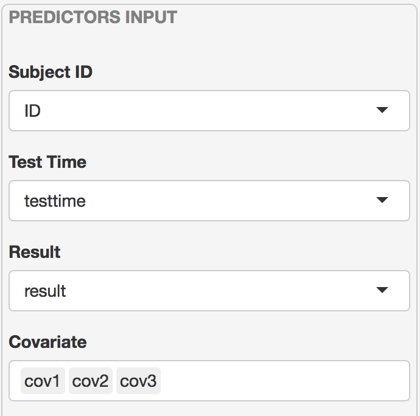

4. Move the slider to choose a value for **Sensitivity** and **Specificity**, then “Submit” to get your analysis results.

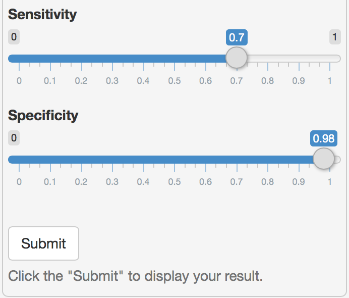